# Sample R Notebook: Getting Started!

# Getting Started with R Markdown

Markdown, in general, is a simplified formatting language designed to easily created documentation pages that can be easily converted to display on the internet (in html format) or in other common report formats (MS Word documents, PDFs, presentation slides). It’s easy to learn, easy to implement, and produces professional-looking reports for your data analysis.

At the base of markdown is the idea of ``literate programming’’, or the idea that code producing results should be embedded in a human-readable explanation of each step of that analysis. Markdown makes it easy to embed code directly into a document, therefore making your analysis fully understandable and reproducible.

R Markdown is a special type of markdown that is designed to work specifically with R and RStudio. You can install R Markdown by running the following bit of code:

```r
install.packages("rmarkdown")
```

|  | binary | source | needs_compilation |
| --- | --- | --- | --- |
| rmarkdown | 2.3 | 2.5 | FALSE |

[output not shown]

Note that R Markdown comes pre-installed in RStudio!

Load the full library by running:

```r
library(rmarkdown)
```

## Template instructions from RStudio:

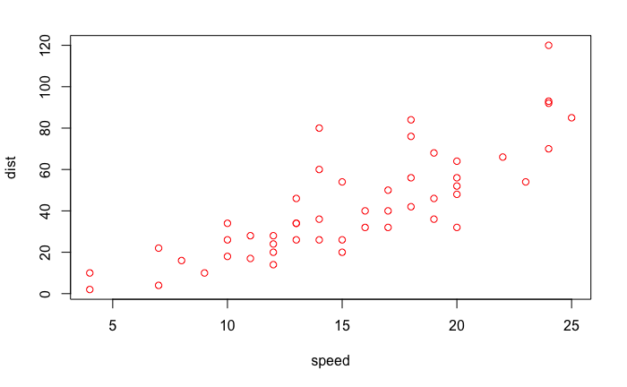

```r
plot(cars,col="red",pch=21)
```

# Other helpful stuff

## Online resources:

- R Markdown Tutorial: https://rmarkdown.rstudio.com/lesson-1.html
- R Markdown Guide book: https://bookdown.org/yihui/rmarkdown/
- See the reference guide in this directory by RStudio: rmarkdown-reference.pdf
- See the Cheat Sheet by R Markdown in this directory: rmarkdown-cheatsheet-2.0.pdf